# TP_Logistics

SHAO Nuoya, BONNET Clément

2020/10/17

## Question 4

On a $\mathbf{H_1} = \mathbf{-X^TVX}$ avec $\mathbf{V}$ la matrice diagonale formée des $\pi_i(1-\pi_i)$. Comme $\pi_i(1-\pi_i)$ est majoré par $\frac{1}{4}$, on construit $\mathbf{H_2} = -\frac{1}{4}\mathbf{X^TIX}$ avec $\mathbf{I}$ la matrice d’identité. Alors on a : $\forall \mathbf{X}\in\mathbf{R^{n*p}}$ avec $\mathbf{X = (x_1^T,...,x_n^T)^T}$
$$\begin{align}
\mathbf{X^T(H_1-H_2)X} &= -\mathbf{\sum_i}(\pi_i(1-\pi_i)-\frac{1}{4})\mathbf{x_ix_i^T} \\
&=\mathbf{\sum_i}(\frac{1}{4}-\pi_i(1-\pi_i))\mathbf{x_ix_i^T}
\end{align}$$
D’où $\mathbf{H_1-H_2}$ est défini-positive car $\pi_i(1-\pi_i) \leq \frac{1}{4}$ et $\mathbf{x_ix_i^T}$ est défini-positive pour $\forall i \in [1,...,n]$

## Question 5

On remplace $\mathbf{H_1}$ par $\mathbf{H_2}$ dans l’équation (6) et on a
$$\begin{align}
\beta^{(s+1)} &= \beta^{(s)}+4(\mathbf{X^TIX})^{-1}\mathbf{X^T}(\mathbf{y-\pi}) \\
&= \beta^{(s)}+4\mathbf{X}^{-1}(\mathbf{y-\pi})
\end{align}$$

## Question 6

L’intérêt de rajouter le terme pénalisé est pour limiter l’overfit. Quand il y a trop de paramètres, la valeur de $L_{\lambda}$ va être très grande, il faut donc la pénaliser. Maximiser $L_\lambda$ par rapport à $\beta$ revient à maximser $L$ et à minimiser en même temps $\vert\vert \beta_\lambda \vert\vert_2^2$. Il s’agit de réaliser un compromis entre ces 2 termes pour diminuer l’overfit sans trop pénaliser la vraissemblance qui aurait pour effet un underfit du training set. Le paramètre $\lambda$ est responsable du compromis.

## Question 7

$$\begin{align}
max_{\beta}\lbrace L_{\lambda}(\beta)\rbrace&=min_{\beta}\lbrace -L_{\lambda}(\beta)\rbrace \\
& = min_{\beta}\lbrace -L_(\beta)+\frac{\lambda}{2}||\beta||_2^2\rbrace
\end{align}$$
On a
$$\begin{align}
-L(\beta) &= -\sum_{i=1}^n \frac{1+y_i}{2}ln[\pi(\mathbf{x_i})] + \frac{1-y_i}{2}ln[1-\pi(\mathbf{x_i})] \\
&= -\frac{1}{2}\sum_{i=1}^n ln[\pi(\mathbf{x_i})(1-\pi(\mathbf{x_i}))] + y_i[ln(\frac{\pi(\mathbf{x_i)}}{1-\pi(\mathbf{x_i})})] \\
&= -\frac{1}{2}\sum_{i=1}^n ln[\pi(\mathbf{x_i})(1-\pi(\mathbf{x_i}))(\frac{\pi(\mathbf{x_i})}{1-\pi(\mathbf{x_i})})^{y_i}] \\
&= -\frac{1}{2}\sum_{i=1}^n ln[\frac{exp(\mathbf{x_i^T}\beta)}{[1+exp(\mathbf{x_i^T}\beta)]^2}exp(y_i\mathbf{x_i^T}\beta)] \\
&= \frac{1}{2}\sum_{i=1}^n ln[(exp(\mathbf{x_i^T}\beta)+2+exp(-\mathbf{x_i^T}\beta))exp(-y_i\mathbf{x_i^T}\beta)] \tag{*}
\end{align}$$
avec
$$(*)=
\left\{
\begin{align}
\frac{1}{2}\sum_{i=1}^n ln^2[1+exp(-\mathbf{x_i^T}\beta)],\ si\ y_i=1 \\
\frac{1}{2}\sum_{i=1}^n ln^2[1+exp(\mathbf{x_i^T}\beta)],\ si\ y_i=-1
\end{align}
\right.$$
$$(*)=
\left\{
\begin{align}
&\sum_{i=1}^n ln[1+exp(-y_i\mathbf{x_i^T}\beta)],\ si\ y_i=1 \\
&\sum_{i=1}^n ln[1+exp(-y_i\mathbf{x_i^T}\beta)],\ si\ y_i=-1
\end{align}
\right.$$
On en déduit que
$$-L(\beta) = \sum_{i=1}^n ln[1+exp(-y_i\beta\mathbf{x_i})]$$
Par conséquent,
$$max_{\beta}\lbrace L_{\lambda}(\beta)\rbrace = min_{\beta}\lbrace\sum_{i=1}^n ln[1+exp(-y_i\mathbf{x_i^T}\beta)]+\frac{\lambda}{2}||\beta||_2^2 \rbrace$$

## Question 8

D’après la définition de $L_{\lambda}(\beta)$, on a $L_{\lambda}(\beta)=L(\beta)-\frac{\lambda}{2}||\beta_{\lambda}||_2^2$. Alors
$$\left\{
\begin{align}
\mathbf{U}(\beta_\lambda) &= \mathbf{U}(\beta) - \lambda\beta_{\lambda} \\
\mathbf{H}(\beta_\lambda) &= \mathbf{H}(\beta) - \lambda
\end{align}
\right.$$
D’où
$$\left\{
\begin{align}
\mathbf{U}(\beta_\lambda) &= \mathbf{X^T}(y-\pi) - \lambda\beta_{\lambda} \\
\mathbf{H}(\beta_\lambda) &= \mathbf{-X^TVX} - \lambda \mathbf{I}_p
\end{align}
\right.$$
Par ailleurs,
$$\begin{align}
\beta^{(s+1)} &= \beta^{(s)}-[\mathbf{H}(\beta^{(s)})]^{-1}\mathbf{U}(\beta^{(s)}) \\
\beta_{\lambda}^{(s+1)}&= \beta_{\lambda}^{(s)} + (\mathbf{X^TVX+\lambda I}_p)^{-1}(\mathbf{X^T}(y-\pi) - \lambda\beta_{\lambda}^{(s)})
\end{align}$$
En remplaçant $\pi_i(1-\pi_i)$ par $\frac{1}{4}$, on a $\mathbf{V} = \mathbf{\frac{I_p}{4}}$ donc on déduit que :
$$\begin{align}
\beta_{\lambda}^{(s+1)} &= \beta_{\lambda}^{(s)} + (\mathbf{X^T \frac{I_p}{4} X+\lambda I}_p)^{-1}(\mathbf{X^T}(y-\pi) - \lambda\beta_{\lambda}^{(s)}) \\
& = \beta_{\lambda}^{(s)} + 4(\mathbf{X^TX+4\lambda I}_p)^{-1}(\mathbf{X^T}(y-\pi) - \lambda\beta_{\lambda}^{(s)})
\end{align}$$

# 3 Cas pratique

## Question 10

```r
data = read.table('Alzheimer_Webster.txt',header = T)
```

```r
X = as.matrix(data[,1:(ncol(data)-1)])
y = as.matrix(data[,ncol(data)])
```

```r
model = cv.glmnet(X, y, alpha=0)
```

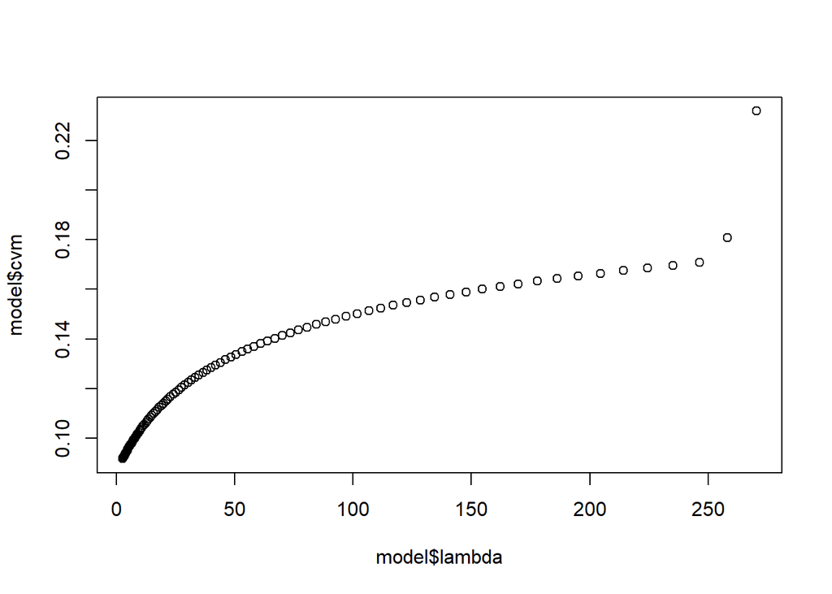

```r
plot(model$lambda, model$cvm, pch=21)
```

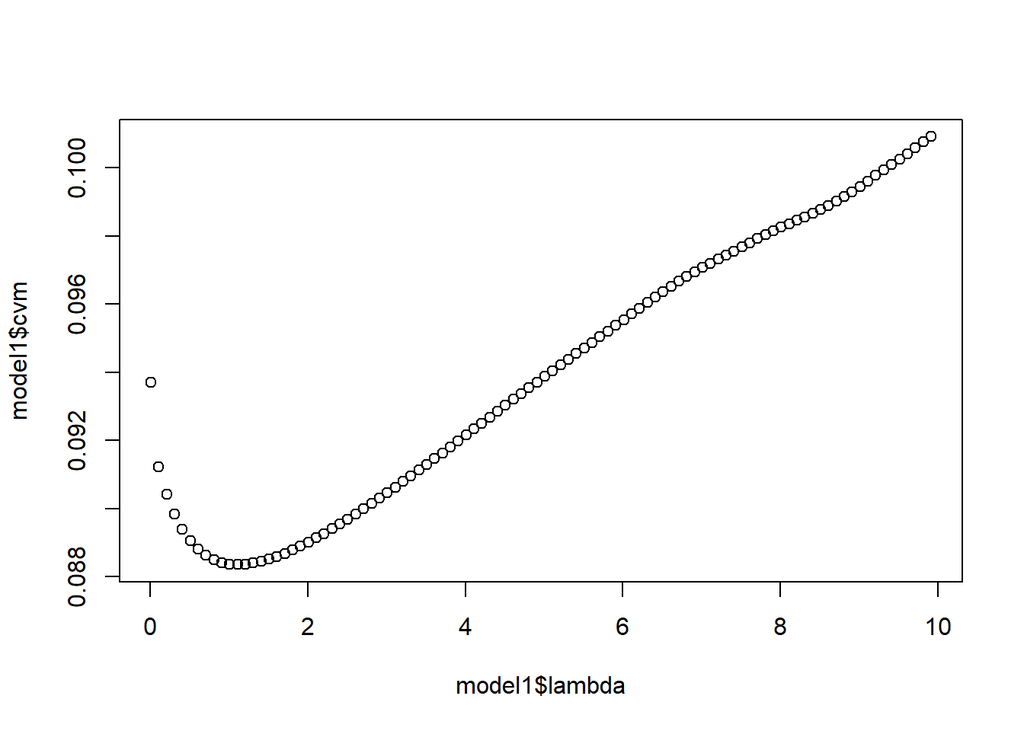

```r
model1 = cv.glmnet(X, y, alpha=0, lambda = seq(0.01, 10, by=0.1))
plot(model1$lambda, model1$cvm, pch=21)
```

## Question 11

```r
A = seq(0, 1, by=0.1)
L = seq(0, 10, by=0.2)
errors = matrix(0, length(A), length(L))

for (i in 1:length(A)){
  Model = cv.glmnet(X, y, alpha = A[i], lambda = L)
  for (j in 1:length(L)){
    errors[i,j] = Model$cvm[j]
  }
}
```

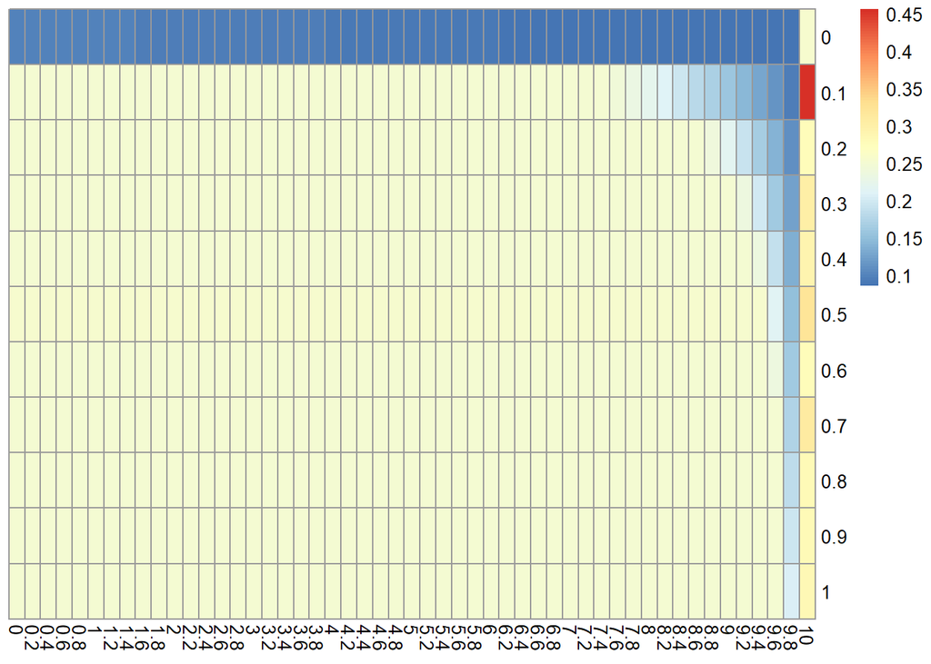

```r
colnames(errors) = L
rownames(errors) = A
pheatmap(errors, display_numbers = F, cluster_rows = F, cluster_cols = F, width = 0.1)
```

```r
A1 = seq(0, 0.1, by=0.01)
L1 = seq(0.5, 1.5, by=0.1)
errors1 = matrix(0, length(A1), length(L1))

for (i in 1:length(A1)){
  Model1 = cv.glmnet(X, y, alpha = A1[i], lambda = L1)
  for (j in 1:length(L1)){
    errors1[i,j] = Model1$cvm[j]
  }
}
```

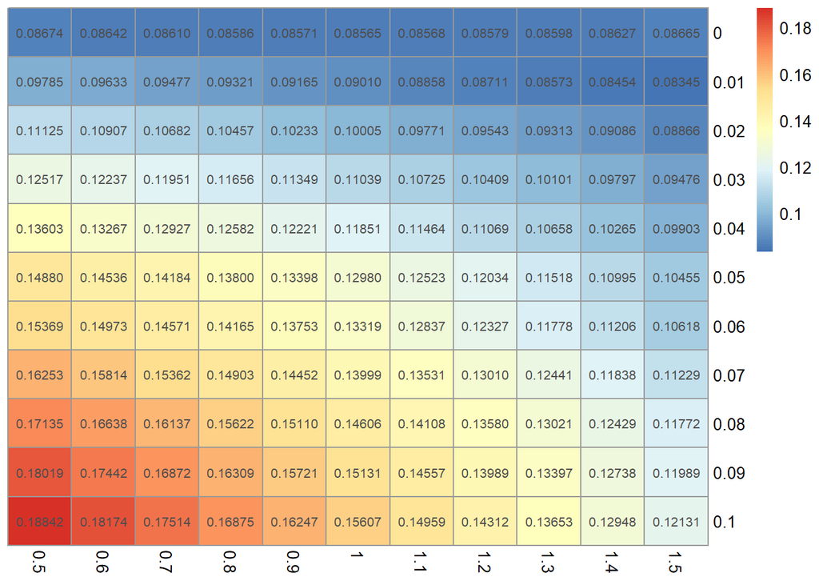

```r
colnames(errors1) = L1
rownames(errors1) = A1
pheatmap(errors1, display_numbers = T, cluster_rows = F, cluster_cols = F, number_format = '%.5f')
```